# MIE237

2016-02-26

## \(R^2\)

The "fit" of a linear model can be summarized by a single number (!):

\[\begin{align*} SST &= SSR + SSE \\ 1 &= \frac{SSR}{SST} + \frac{SSE}{SST}\\ R^2 &= \frac{SSR}{SST}\end{align*}\]

This is a moderately useful number that also goes by a unfortunately dramatic-sounding "coefficient of determination" and can be interpreted as "the proportion of variation explained by the model".

But in the end it is just a single number that summarizes an *entire bivariate linear relationship*, so don't take it too seriously.

## Examples

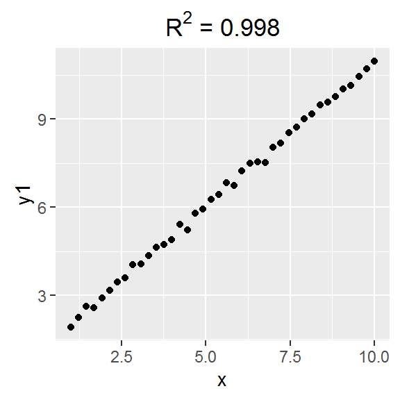

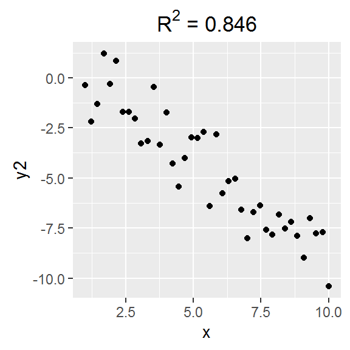

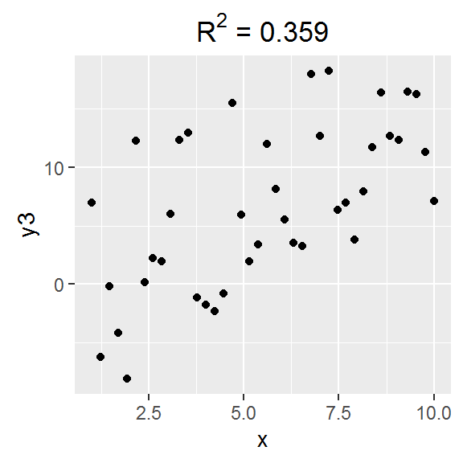

## Limitations: "Model assumptions"

Assumes linear model is appropriate to begin with.

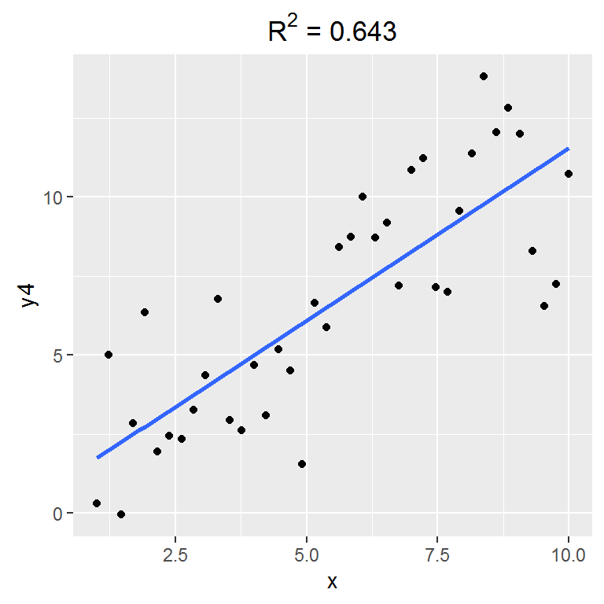

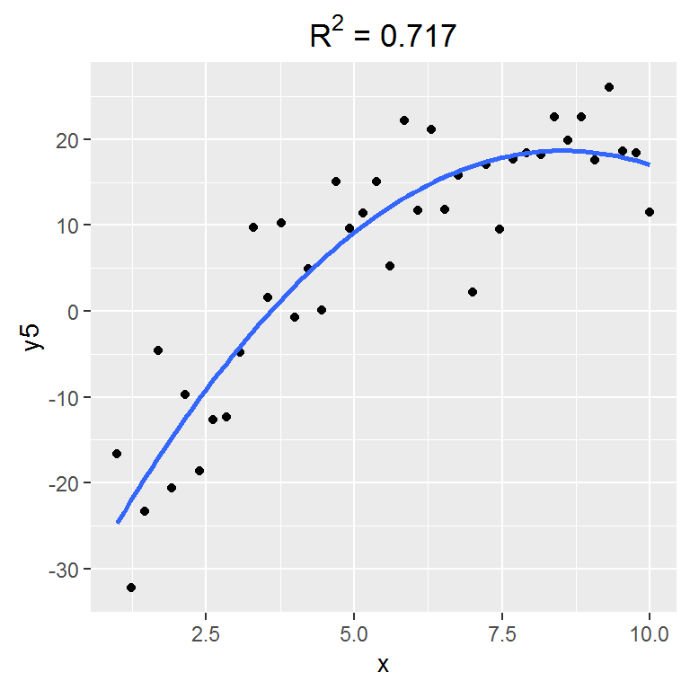

## Limitations: sample size/variability

Both simulated datasets are from the *same underlying model*

(happens to be \(y_i = 1 + 1 \cdot x_i + \varepsilon\) with \(\varepsilon \sim N(0, 4)\))

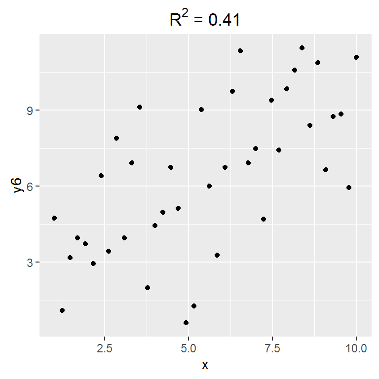

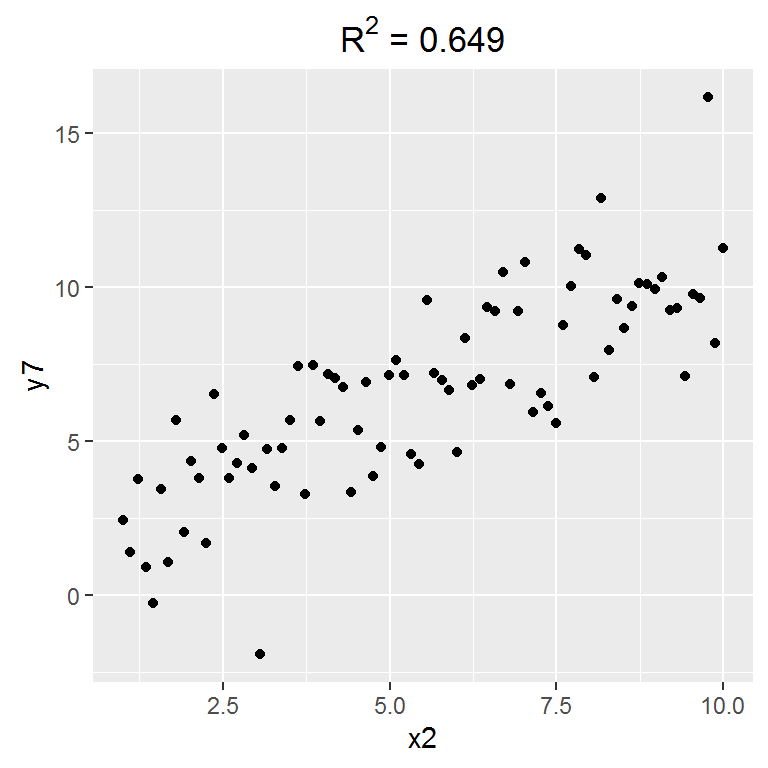

## New topic: estimating the mean response

Suppose you want to estimate the mean "response" at some new \(x_0\) (mayor may not be one of the original \(x\)'s.) Let's call this number \(E(Y(x_0))\).

(Book calls this number \(\mu_{Y|x_0}\).)

The *true value* for the mean response is:\[\beta_0 + \beta_1 x_0\]

What's the obvious best guess?\[\hat\beta_0 + \hat\beta_1 x_0\]

We can make a confidence interval in the "usual manner".

## Confidence interval for the mean response

"As usual" will be based on:\[\frac{(\hat\beta_0 + \hat\beta_1 x_0) - (\beta_0 + \beta_1 x_0)}{SE(\hat\beta_0 + \hat\beta_1 x_0)} \sim \quad ???\]where SE means "standard error".

In what follows keep in mind: \(y_i\), \(\hat\beta_0\) and \(\hat\beta_1\) are *random* while the \(x_i\) are *fixed*.

\[\begin{align*} {\text{Var}\left( \hat\beta_0 + \hat\beta_1 x_0 \right)} &= {\text{Var}\left( {\overline{y}} - \hat\beta_1{\overline{x}} + \hat\beta_1 x_0 \right)}\\ &= {\text{Var}\left( {\overline{y}} + \hat\beta_1(x_0 - {\overline{x}}) \right)}\\ &= \frac{\sigma^2}{n} + \frac{\sigma^2}{S_{xx}}(x_0 - {\overline{x}})^2 + \text{Cov}({\overline{y}}, \hat\beta_1) \end{align*}\]

## CI for the mean response

It turns out \(\text{Cov}({\overline{y}}, \hat\beta_1) = 0\). *(Book sez "see ex. 11.61" but the question is just "prove it!" with no suggestion on how to proceed!)*

So we end up with:\[{\text{Var}\left( \hat\beta_0 + \hat\beta_1 x_0 \right)} = \sigma^2\left(\frac{1}{n} + \frac{(x_0 - {\overline{x}})^2}{S_{xx}}\right)\]

Conclusion:\[\frac{(\hat\beta_0 + \hat\beta_1 x_0) - (\beta_0 + \beta_1 x_0)}{s\sqrt{\left(\frac{1}{n} + \frac{(x_0 - {\overline{x}})^2}{S_{xx}}\right)}} \sim \quad ???\]

## Example

I'll use the last simulated example from above (`x2` versus `y7`)

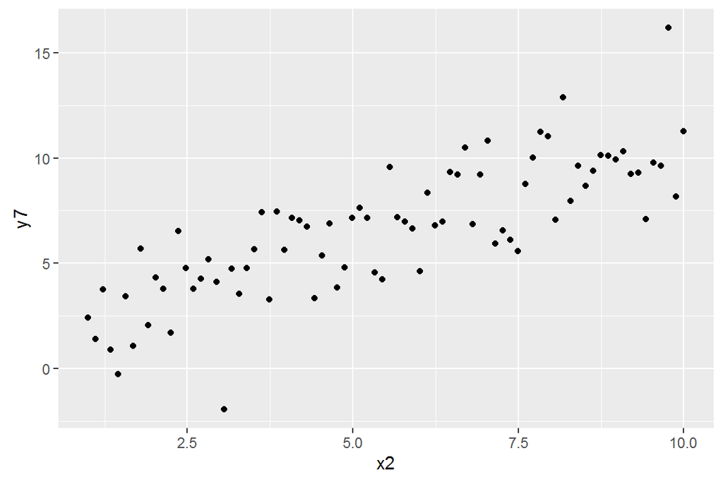

Let's find confidence intervals for the mean response at \(x_0 = 5.0\).

## Example

| term | estimate | std.error | statistic | p.value |
| --- | --- | --- | --- | --- |
| (Intercept) | 1.344 | 0.488 | 2.756 | 0.007 |
| x2 | 0.961 | 0.080 | 12.012 | 0.000 |

Also:

\[\begin{align*} s = \sqrt{\text{MSE}} &= 1.882\\ {\overline{x}} &= 5.5\\ S_{xx} &= 553.671 \end{align*}\]

The 95% confidence interval is:\[1.344 + 0.961 \cdot 5 \pm t_{n-2, 0.025} 1.882 \sqrt{\frac{1}{80} + \frac{(5 - 5.5)^2}{553.671}} = 6.148 \pm 0.426\]

## graphic of pointwise CIs across range of x

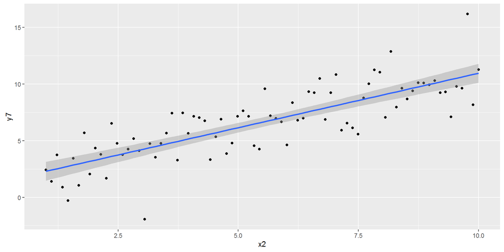

## New topic (technically!) predicting a new response

Suppose you want to predict the ``response'' at some new \(x_0\) (mayor may not be one of the original \(x\)'s.) Let's call this \(Y(x_0)\).

Important: \(Y(x_0)\) is a *random variable*.

The true value \(Y(x_0)\) isn't known, except it is normal with  
mean \(\beta_0+\beta_1x_0\) and variance \(\sigma^2\).

The obvious best guess is \(\hat Y(x_0) = \hat\beta_0 + \hat\beta_1 x_0\).

(Danger Zone: same *guess* as for \(E(Y(x_0))\). But this is a fundamentally different problem.)

## Prediction interval (PI) for new response

"As usual" based on:\[\frac{\hat Y(x_0) - Y(x_0)}{SE\left(\hat Y(x_0) - Y(x_0)\right)} \sim \quad ???\]

Proceed somewhat like before, but actually easier:\[\begin{align*} {\text{Var}\left( \hat Y(x_0) - Y(x_0) \right)} &= {\text{Var}\left( \hat Y(x_0) \right)} + {\text{Var}\left( Y(x_0) \right)}\\ &=\sigma^2\left(\frac{1}{n} + \frac{(x_0-\overline x)^2}{S_{xx}}\right) +{\sigma^2}\\ &=\sigma^2\left(1+\frac{1}{n} + \frac{(x_0-\overline x)^2}{S_{xx}}\right) \end{align*}\]

## Prediction interval (PI) for new response

Conclusion:\[\frac{\hat Y(x_0) - Y(x_0)}{s\sqrt{1 + \left(\frac{1}{n} + \frac{(x_0 - {\overline{x}})^2}{S_{xx}}\right)}} \sim \quad ???\]

## Example

From the previous example, the 95% PI for \(Y(5.0)\) is:

\[1.344 + 0.961 \cdot 5 \pm t_{n-2, 0.025} 1.882 \sqrt{1 + \frac{1}{80} + \frac{(5 - 5.5)^2}{553.671}} = 6.148 \pm 3.771\]

## graphic of pointwise PIs across range of x

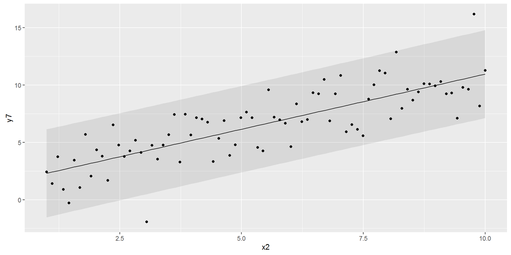